# Normal Distribution

10/21/2015

```r
require(mosaic)
require(oilabs)
```

##### Question 1

Now let’s consider some of the other variables in the body dimensions data set. Using the figures below, match the histogram to its normal probability plot. All of the variables have been standardized (first subtract the mean, then divide by the standard deviation), so the units won’t be of any help. If you are uncertain based on these figures, generate the plots in R to check.

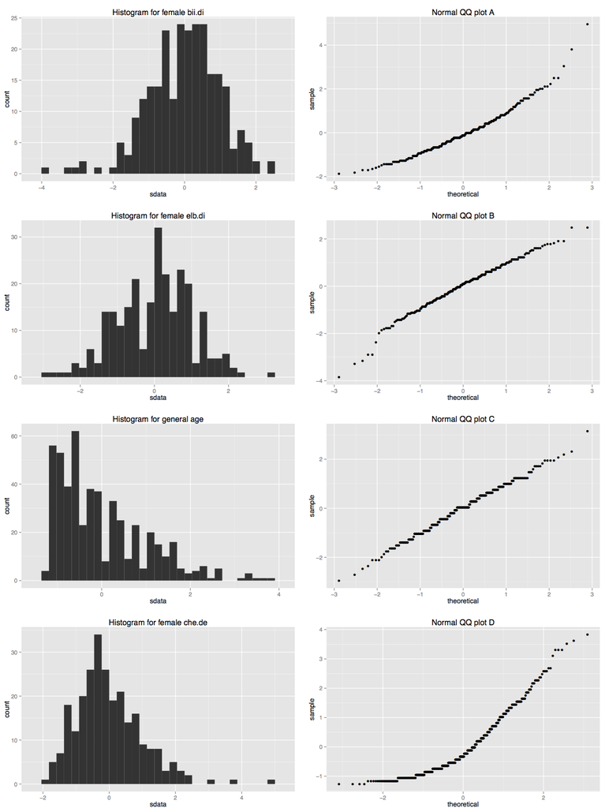

##### Question 2

Note that normal probability plots C and D have a slight stepwise pattern. Why do you think this is the case?

##### Question 3

As you can see, normal probability plots can be used both to assess normality and visualize skewness. Make a normal probability plot for female knee diameter ($kne.di$). Based on this normal probability plot, is this variable left skewed, symmetric, or right skewed? Use a histogram to confirm your findings.